# TweetsReport

## Tuiteros mas activos

I can’t seem to find the official figure anywhere, but ISME says that its symposia typically attract [between 1500 and 2500 delegates](http://www.isme-microbes.org/isme16/practical), which I would say felt about right. How many people were tweeting using the #ISME16 hashtag, and who was the most active? The most favorited/retweeted?

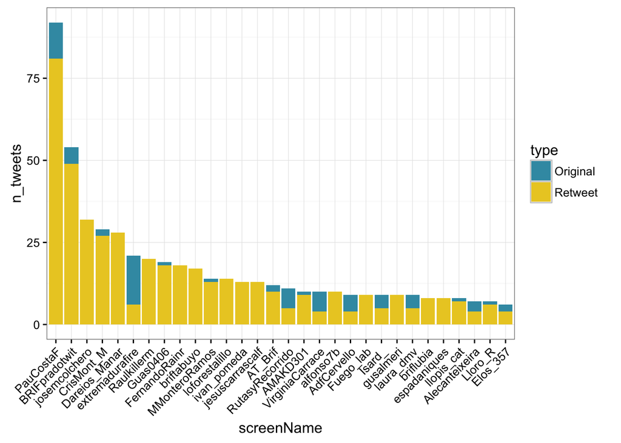

```r
# Todos los tweets

top_users %>%
  transform(screenName = reorder(screenName, -n_tweets)) %>% # Order descending
  ggplot(aes(screenName, n_tweets,fill = type)) +
    geom_bar(aes(x = screenName, y = n_tweets, fill = type),stat = "identity") +
    scale_fill_manual(values = wes_palette("Zissou")[c(1, 3)]) +
    theme_bw() +
    theme(axis.text.x = element_text(angle = 45, hjust = 1))
```

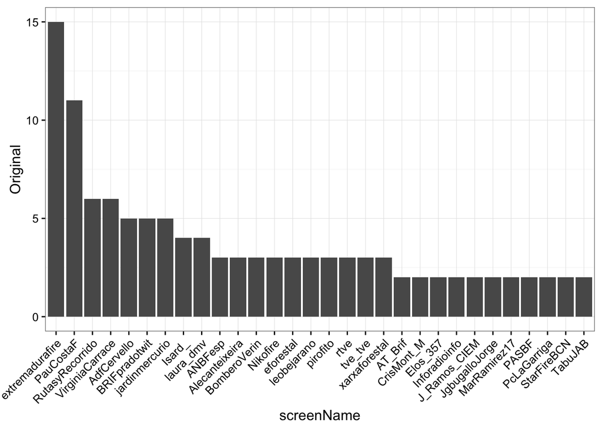

```r
top_orig_users %>% slice(1:30) %>%
  transform(screenName = reorder(screenName, -Original)) %>% # Order descending
  ggplot(aes(screenName, Original)) + geom_bar(stat = "identity") +
  theme_bw() + theme(axis.text.x = element_text(angle = 45, hjust = 1))
```

## Los 5 tweets mas marcados como favoritos:

> ü¾¦¼Por quü¾¼ es tan importante interpretar ‘La huella del fuego’? Lo descubrimos a las 23.30 h en La2 #CRincendiosü¾“ ¼ https://t.co/QpRcCr0n1t

> — rtve | [2016-11-28](https://twitter.com/rtve/status/803318323354046464) | 63 retweets, 52 favorites.

> Viendo ahora el gran programa #CRincendios. En vez de echar este tipo de programas a estas horas deberü¾¼a ser en ’prü¾“ ¼ https://t.co/rUpwBasDR0

> — eforestal | [2016-11-28](https://twitter.com/eforestal/status/803374524490272768) | 29 retweets, 47 favorites.

> #CRincendios Si nosotros no gestionamos el monte, lo harü¾¼ el fuego. Maü¾¼ana en #Crü¾¶¼nicas ‘La huella del fuego’ ü¾“ ¼ https://t.co/HG5wSaPgfg

> — rtve | [2016-11-27](https://twitter.com/rtve/status/802967734514577408) | 44 retweets, 41 favorites.

> #CRincendios @PauCostaF @la2_tve muy buen programa. Mensaje transmitido por buenos profesionales de la comunicaciü¾¶¼n. Un gusto trabajar asi!

> — incendi | [2016-11-29](https://twitter.com/incendi/status/803505556715696128) | 20 retweets, 38 favorites.

> Arranca en La2 ‘La huella del fuego’, un reportaje sobre la importancia de la gestiü¾¶¼n forestal. DIRECTOü¾“ ¼ https://t.co/ObLcKlyM4n

> — tve_tve | [2016-11-28](https://twitter.com/tve_tve/status/803365209511514112) | 25 retweets, 37 favorites.

## Los 5 tweets mas retuiteados:

> ü¾¦¼Por quü¾¼ es tan importante interpretar ‘La huella del fuego’? Lo descubrimos a las 23.30 h en La2 #CRincendiosü¾“ ¼ https://t.co/QpRcCr0n1t

> — rtve | [2016-11-28](https://twitter.com/rtve/status/803318323354046464) | 63 retweets, 52 favorites.

> #CRincendios Si nosotros no gestionamos el monte, lo harü¾¼ el fuego. Maü¾¼ana en #Crü¾¶¼nicas ‘La huella del fuego’ ü¾“ ¼ https://t.co/HG5wSaPgfg

> — rtve | [2016-11-27](https://twitter.com/rtve/status/802967734514577408) | 44 retweets, 41 favorites.

> Si te perdiste ayer Crü¾¶¼nicas - La huella del fuego, Crü¾¶¼nicas - RTVE.es A la Carta #CRIncendios #IIFF https://t.co/nwfJPQqnDO vü¾¼a @rtve

> — AT_Brif | [2016-11-29](https://twitter.com/AT_Brif/status/803483823862415360) | 34 retweets, 28 favorites.

> “Nuestro sistema de extinciü¾¶¼n es de los mejores dl mundo” Yo aü¾¼ado: y la gente q curra en ellos los mü¾¼s olvidados y ninguneados #CRincendios

> — TamerScylla | [2016-11-28](https://twitter.com/TamerScylla/status/803371144925642752) | 34 retweets, 21 favorites.

> ‘La huella del fuego’, el lunes 28 de noviembre a las 23:30h en @la2_tve #CRincendios https://t.co/abzeXQM32I via @rtve

> — PauCostaF | [2016-11-25](https://twitter.com/PauCostaF/status/802232076988805120) | 34 retweets, 21 favorites.

## Usuarios que han recibido mas retuits/favoritos:

### Numero total de favoritos recibidos por los usuarios

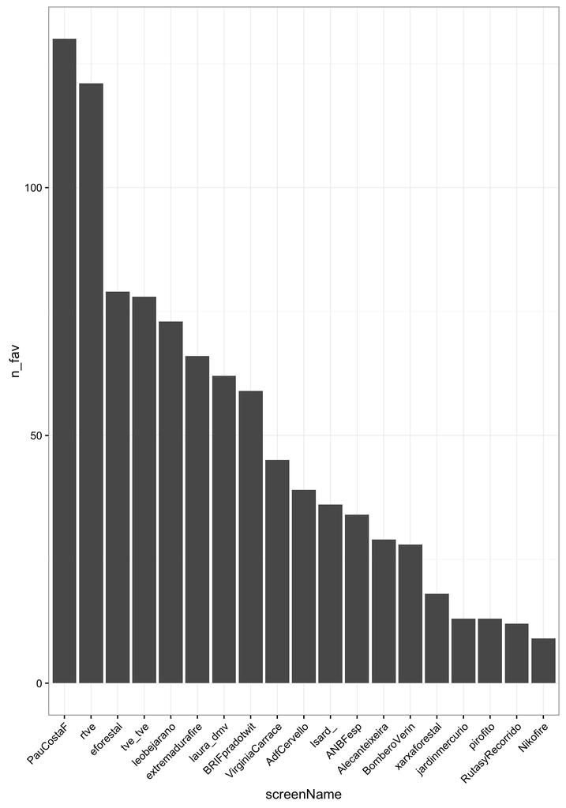